Skip to main content

# Space-time Hawkes process: simulation and maximum-likelihood fitting

This notebook explains, line by line, the Python code in `src/stpp/hawkes.py`:

1. the **model**,
2. the **simulator** (a Python port of Robert’s `R/simulate_hawkes_clustering.R`),
3. the **mathematics of fitting** by maximum likelihood,
4. the **fitting code**, and
5. a check that the fit recovers the true parameters.

# 1. The model

We observe events $(t_i, x_i, y_i)$, $i = 1, \dots, n$, in a time window $[0, T]$ and a rectangle $W = [x_{\min}, x_{\max}] \times [y_{\min}, y_{\max}]$. A point process is described by its **conditional intensity**: the instantaneous rate of events at $(t, x, y)$, given everything that happened before $t$ (the history $\mathcal H_t$):

$$\lambda(t, x, y \mid \mathcal H_t) \;\approx\;
\frac{P(\text{an event in } [t, t+dt] \times [x, x+dx] \times [y, y+dy] \mid \mathcal H_t)}{dt\,dx\,dy}.$$

Our space-time Hawkes model is

$$\lambda(t, x, y) \;=\; \mu \;+\; \sum_{j:\, t_j < t}
\underbrace{K}_{\text{how many}}\;
\underbrace{\beta e^{-\beta (t - t_j)}}_{\text{when}}\;
\underbrace{\frac{1}{2\pi\sigma^2}\exp\!\Big(-\frac{(x-x_j)^2 + (y-y_j)^2}{2\sigma^2}\Big)}_{\text{where}}.$$

| Parameter | Meaning |
| --- | --- |
| $\mu$ | background rate: events per unit time per unit area that arrive “out of nowhere” |
| $K$ | branching ratio: expected number of direct children of each event |
| $\beta$ | temporal decay: a child arrives on average $1/\beta$ time units after its parent |
| $\sigma$ | spatial spread: children land a Gaussian distance $\sigma$ (per coordinate) from the parent |

The “when” factor integrates to 1 over $(0, \infty)$ and the “where” factor integrates to 1 over the plane. So each past event adds a bump of total mass exactly $K$: on average it triggers $K$ children. That is why $K$ is the branching ratio.

**Branching (cluster) view.** The same model can be generated in two steps:

- *Immigrants*: a homogeneous Poisson process with rate $\mu$ on $[0, T] \times W$.
- *Offspring*: each event, immigrant or child, independently has $\text{Poisson}(K)$ children. Each child’s delay is $\text{Exp}(\beta)$ and its displacement is $N(0, \sigma^2)$ in each of $x$ and $y$.

Each immigrant starts a family tree. The expected tree size is $1 + K + K^2 + \dots = 1/(1-K)$, which is finite only when $K < 1$ (a *subcritical* process). With $K \ge 1$ the cascades never die out. So the expected number of events is about

$$E[N] \approx \frac{\mu\,|W|\,T}{1 - K}.$$

# 2. The simulator, line by line

The simulator uses the branching view directly: generate immigrants, then generation after generation of children, until a generation has no children.

```python
def simulate_hawkes(tmax, W, mu, K, beta, sigma, seed=None, clip=True):
    if not 0 <= K < 1:
        raise ValueError("K must be in [0, 1); ...")
    rng = np.random.default_rng(seed)
    xmin, xmax, ymin, ymax = W
    area = (xmax - xmin) * (ymax - ymin)

    n_bg = rng.poisson(mu * area * tmax)
    gen_t = rng.uniform(0, tmax, n_bg)
    gen_x = rng.uniform(xmin, xmax, n_bg)
    gen_y = rng.uniform(ymin, ymax, n_bg)
    all_t, all_x, all_y = [gen_t], [gen_x], [gen_y]

    while gen_t.size > 0:
        n_children = rng.poisson(K, gen_t.size)
        par_t = np.repeat(gen_t, n_children)
        par_x = np.repeat(gen_x, n_children)
        par_y = np.repeat(gen_y, n_children)
        m = par_t.size
        gen_t = par_t + rng.exponential(1 / beta, m)
        gen_x = par_x + rng.normal(0, sigma, m)
        gen_y = par_y + rng.normal(0, sigma, m)
        all_t.append(gen_t)
        all_x.append(gen_x)
        all_y.append(gen_y)

    events = np.column_stack([np.concatenate(all_t),
                              np.concatenate(all_x),
                              np.concatenate(all_y)])
    if clip:
        t, x, y = events.T
        inside = (t <= tmax) & (x >= xmin) & (x <= xmax) & (y >= ymin) & (y <= ymax)
        events = events[inside]
    return events[np.argsort(events[:, 0])]
```

**1**

Refuse $K \ge 1$. A supercritical process explodes and the `while` loop would never end. (The R version has no such check.)

**2**

A random-number generator. Passing `seed` makes a simulation reproducible.

**3**

Unpack the window $W = (x_{\min}, x_{\max}, y_{\min}, y_{\max})$, as in the R code.

**4**

$|W|$, the area of the rectangle.

**5**

**Number of immigrants.** For a Poisson process with rate $\mu$ on a region of volume $|W|\,T$, the count is $\text{Poisson}(\mu |W| T)$. This is R’s `rpois(1, lambda = total_n)`.

**6**

**Where and when the immigrants are.** Given the count, a homogeneous Poisson process puts its points independently and uniformly over the region. Same as R’s three `runif` calls.

**7**

Lists that collect every generation. The current generation is held in `gen_*`.

**8**

Keep going while the current generation has at least one event. A generation’s size is on average $K$ times the previous one’s, so with $K < 1$ the loop ends quickly.

**9**

**How many children** each event in the current generation has: one independent $\text{Poisson}(K)$ draw per event. Same as R’s `rpois(homog_p, K)`.

**10**

`np.repeat` copies each parent’s time and location once per child. A parent with 3 children appears 3 times and a parent with 0 children disappears. This replaces R’s `[off_n > 0]` filter and its `for (i in ...)` loop over parents with one vectorised step.

**11**

`m` is the total number of children in the new generation.

**12**

**Child time = parent time + Exp($\beta$) delay.** NumPy’s `exponential` takes the *mean* $1/\beta$, while R’s `rexp(..., rate = beta)` takes the rate. They give the same distribution. The exponential density $\beta e^{-\beta u}$ is exactly the “when” factor in $\lambda$.

**13**

**Child location = parent location + $N(0, \sigma^2)$** in each coordinate, independently. The resulting 2-D density is the “where” factor in $\lambda$. Same as R’s `rnorm`.

**14**

Save the new generation. On the next pass of the loop the children become the parents.

**15**

Stack all generations into an $n \times 3$ array with columns $(t, x, y)$.

**16**

**Clipping.** Children can land after $T$ or outside $W$. In real data we would never see them, so by default we drop them. The R version keeps them, which is equivalent to `clip=False` here. The likelihood below assumes we only see events inside the window.

**17**

Sort by time. The likelihood needs to know which events came before which.

Robert’s file currently has four functions (`_temporal`, `_spatial`, `_bg` and the base one). Their bodies are identical for now. They look like placeholders for variants with a different temporal kernel (`_temporal` loads `poweRlaw`, so probably a power-law delay instead of an exponential one), a different spatial kernel, and a non-constant background. This notebook covers the base model.

## Running it

```python
import numpy as np
import matplotlib.pyplot as plt
from stpp.hawkes import simulate_hawkes, fit_hawkes

truth = {"mu": 0.05, "K": 0.5, "beta": 1.0, "sigma": 0.3}
T, W = 100.0, (0.0, 10.0, 0.0, 10.0)

events = simulate_hawkes(T, W, **truth, seed=0)
t, x, y = events.T
print(f"{len(events)} events; rough expectation mu*|W|*T/(1-K) = "
      f"{truth['mu'] * 100 * T / (1 - truth['K']):.0f} (minus edge losses)")
```

```
862 events; rough expectation mu*|W|*T/(1-K) = 1000 (minus edge losses)
```

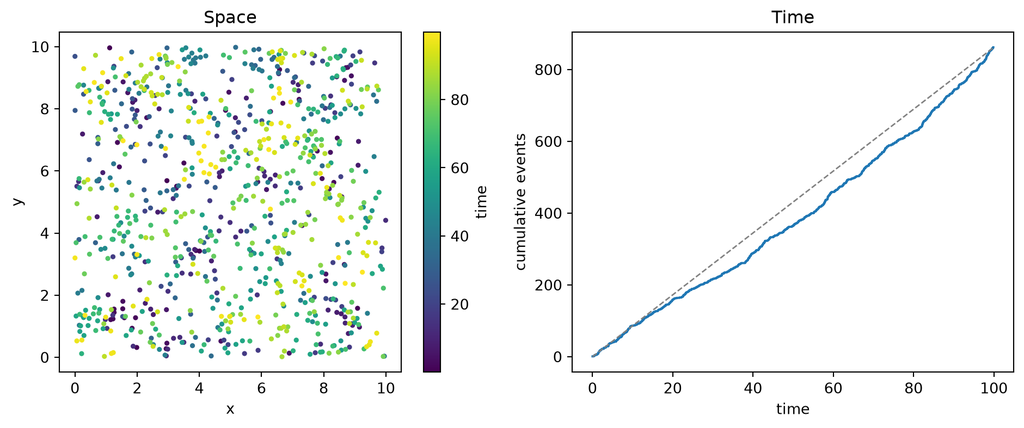

Left: event locations, coloured by time. Clusters are families of triggered events. Right: cumulative count over time. The jumps are cascades, and a Poisson process would give a straight line.

```python
fig, axes = plt.subplots(1, 2, figsize=(10, 4.2))
sc = axes[0].scatter(x, y, c=t, s=6, cmap="viridis")
axes[0].set(xlabel="x", ylabel="y", aspect="equal", title="Space")
fig.colorbar(sc, ax=axes[0], label="time")
axes[1].step(t, np.arange(1, len(t) + 1), where="post")
axes[1].plot([0, T], [0, len(t)], ls="--", c="grey", lw=1)
axes[1].set(xlabel="time", ylabel="cumulative events", title="Time")
plt.tight_layout()
```

# 3. The mathematics of fitting

We want the parameters $\theta = (\mu, K, \beta, \sigma)$ that make the observed events most probable: the **maximum-likelihood estimate** (MLE).

## 3.1 The point-process likelihood

Cut $[0, T] \times W$ into tiny cells of volume $\Delta = dt\,dx\,dy$. Given the past, each cell contains

- one event with probability $\approx \lambda(t, x, y)\,\Delta$, or
- no event with probability $\approx 1 - \lambda\Delta \approx e^{-\lambda \Delta}$.

The probability of the whole observed pattern is the product over cells: a factor $\lambda(t_i, x_i, y_i)\,\Delta$ for each of the $n$ cells that hold an event, and $e^{-\lambda \Delta}$ for every empty cell. As the cells shrink, the product of the empty-cell factors becomes $\exp\!\big(-\int\!\!\int\!\!\int \lambda\big)$. Dropping the constant $\Delta^n$ and taking logs gives the standard point-process log-likelihood:

$$\boxed{\;\ell(\theta) \;=\; \sum_{i=1}^{n} \log \lambda(t_i, x_i, y_i)
\;-\; \underbrace{\int_0^T\!\!\int_W \lambda(t, x, y)\,dx\,dy\,dt}_{\Lambda(\theta),\ \text{the compensator}}\;}$$

The two terms pull in opposite directions:

- The **first term** rewards a high intensity *where events actually happened*.
- The **compensator** $\Lambda$ is the expected number of events the model predicts in the window. It penalises a high intensity *everywhere*.

Without the penalty, the fit would simply make $\lambda$ huge. The MLE balances the two. In fact, at the optimum the expected count equals the observed count, $\Lambda(\hat\theta) = n$.

## 3.2 The first term: $\log \lambda$ at each event

Plug the model into $\lambda(t_i, x_i, y_i)$. Only events strictly earlier than $t_i$ contribute:

$$\lambda_i = \mu + \sum_{j:\, t_j < t_i} K \beta e^{-\beta \Delta t_{ij}}
\frac{1}{2\pi\sigma^2} e^{-d_{ij}^2 / (2\sigma^2)},
\qquad \Delta t_{ij} = t_i - t_j,\;\; d_{ij}^2 = (x_i - x_j)^2 + (y_i - y_j)^2.$$

$\Delta t_{ij}$ and $d^2_{ij}$ do not depend on $\theta$, so we compute them **once** for every pair $j < i$ and reuse them on each likelihood evaluation.

## 3.3 The compensator in closed form

Integrate term by term. The background is a constant, so its integral is $\mu\,|W|\,T$. For the bump of each past event $j$, time and space factorise:

**Time.** The bump starts at $t_j$ and is cut off at $T$:
$$\int_{t_j}^{T} \beta e^{-\beta (t - t_j)}\,dt = 1 - e^{-\beta (T - t_j)}.$$
An event near the end of the window has had little time to trigger children, so it gets less than its full mass.

**Space.** A 2-D Gaussian with independent coordinates integrates over a rectangle as a product of two 1-D normal probabilities ($\Phi$ is the standard normal CDF):
$$\int_W \frac{e^{-d^2/(2\sigma^2)}}{2\pi\sigma^2}\,dx\,dy =
\Big[\Phi\big(\tfrac{x_{\max} - x_j}{\sigma}\big) - \Phi\big(\tfrac{x_{\min} - x_j}{\sigma}\big)\Big]
\Big[\Phi\big(\tfrac{y_{\max} - y_j}{\sigma}\big) - \Phi\big(\tfrac{y_{\min} - y_j}{\sigma}\big)\Big].$$
An event near the edge of $W$ sends some of its children outside, where we can’t see them.

So

$$\Lambda(\theta) = \mu |W| T + K \sum_{j=1}^{n}
\big(1 - e^{-\beta (T - t_j)}\big)\, P^x_j(\sigma)\, P^y_j(\sigma).$$

These two edge corrections are what make the estimates unbiased even though we clipped the data in the simulator.

## 3.4 Maximising

There is no closed-form maximiser, so we maximise $\ell$ numerically.

- **Reparametrise on the log scale.** All four parameters must be positive. We optimise over $\phi = \log\theta$, which can be any real number, so the optimiser can’t step into impossible values such as $\sigma < 0$.
- **Minimise $-\ell(\phi)$ with BFGS**, a quasi-Newton method. It builds up an approximation to the curvature from successive gradients. SciPy computes the gradient by finite differences.
- **Standard errors.** For large samples the MLE is approximately normal with covariance equal to the inverse of the *observed Fisher information*. That is the Hessian (matrix of second derivatives) of $-\ell$ at the optimum:
  $$\widehat{\text{Cov}}(\hat\phi) = \big[\nabla^2 (-\ell)(\hat\phi)\big]^{-1}.$$
  A sharply curved likelihood means a well-determined parameter and a small standard error.
- **Delta method back to the original scale.** $\theta = e^\phi$ gives $d\theta/d\phi = e^\phi = \theta$, so
  $$\text{SE}(\hat\theta) \approx \hat\theta \cdot \text{SE}(\hat\phi).$$

**Cost.** The pairwise sum is $O(n^2)$. That is fine for a few thousand events: the fit below takes under a second. For large catalogues or order books you would truncate pairs with large $\Delta t$ or $d$, where the kernel is negligible.

# 4. The fitting code, line by line

## Pairwise gaps

```python
def _pairs(events):
    t, x, y = events.T
    i, j = np.tril_indices(len(t), k=-1)
    dt = t[i] - t[j]
    d2 = (x[i] - x[j]) ** 2 + (y[i] - y[j]) ** 2
    return i, dt, d2
```

**1**

Split the $n \times 3$ array into its three columns.

**2**

Every index pair $(i, j)$ with $j < i$, i.e. the strict lower triangle of an $n \times n$ matrix. The events are sorted by time, so $j < i$ means “$j$ happened before $i$”. This gives $n(n-1)/2$ pairs.

**3**

$\Delta t_{ij} = t_i - t_j > 0$.

**4**

$d^2_{ij}$, the squared distance. These two vectors don’t depend on $\theta$, so they’re computed once (§3.2).

## Negative log-likelihood

```python
def neg_log_likelihood(theta, events, tmax, W, pairs=None):
    mu, K, beta, sigma = np.exp(theta)
    t, x, y = events.T
    n = len(t)
    xmin, xmax, ymin, ymax = W
    i, dt, d2 = pairs if pairs is not None else _pairs(events)

    g = K * beta * np.exp(-beta * dt) \
        * np.exp(-d2 / (2 * sigma**2)) / (2 * np.pi * sigma**2)
    lam = mu + np.bincount(i, weights=g, minlength=n)
    log_lam_sum = np.sum(np.log(lam))

    time_mass = 1 - np.exp(-beta * (tmax - t))
    px = norm.cdf((xmax - x) / sigma) - norm.cdf((xmin - x) / sigma)
    py = norm.cdf((ymax - y) / sigma) - norm.cdf((ymin - y) / sigma)
    area = (xmax - xmin) * (ymax - ymin)
    compensator = mu * area * tmax + K * np.sum(time_mass * px * py)

    return -(log_lam_sum - compensator)
```

**1**

The optimiser works with $\phi = \log\theta$ (§3.4). Exponentiate to get the actual parameters, which are always positive.

**2**

Reuse the precomputed pair arrays if they were passed in. This saves an $O(n^2)$ step on every call.

**3**

The triggering contribution of event $j$ to event $i$, for every pair at once: $K\beta e^{-\beta\Delta t_{ij}}\,\frac{1}{2\pi\sigma^2}e^{-d^2_{ij}/2\sigma^2}$.

**4**

**$\lambda_i$.** `np.bincount(i, weights=g)` adds up `g` over all pairs that share the same $i$, giving $\sum_{j<i}(\cdot)$ for each event. `minlength=n` makes sure event 0, which has no earlier events, gets a 0. Then add the background $\mu$.

**5**

First term of $\ell$: $\sum_i \log\lambda_i$.

**6**

Time part of the compensator: $1 - e^{-\beta(T - t_j)}$ for each event (§3.3).

**7**

Space part: the share of each event’s Gaussian that lies inside $W$, as a product of normal-CDF differences (§3.3).

**8**

$\Lambda(\theta) = \mu|W|T + K\sum_j (\text{time share})(\text{space share})$.

**9**

Return $-\ell$, because optimisers *minimise*.

## Fitting and standard errors

```python
def _numerical_hessian(f, theta, h=1e-4):
    k = len(theta)
    H = np.zeros((k, k))
    for a in range(k):
        for b in range(a, k):
            ea, eb = np.eye(k)[a] * h, np.eye(k)[b] * h
            H[a, b] = H[b, a] = (
                f(theta + ea + eb) - f(theta + ea - eb)
                - f(theta - ea + eb) + f(theta - ea - eb)
            ) / (4 * h * h)
    return H

def fit_hawkes(events, tmax, W, start=(0.1, 0.5, 1.0, 1.0)):
    pairs = _pairs(events)

    def f(theta):
        return neg_log_likelihood(theta, events, tmax, W, pairs)

    res = minimize(f, np.log(start), method="BFGS")
    est = np.exp(res.x)
    cov_log = np.linalg.inv(_numerical_hessian(f, res.x))
    se = est * np.sqrt(np.diag(cov_log))
    return HawkesFit(estimate=dict(zip(PARAM_NAMES, est)),
                     std_error=dict(zip(PARAM_NAMES, se)),
                     log_likelihood=-res.fun,
                     converged=bool(res.success))
```

**1**

The Hessian is symmetric, so we only compute the upper triangle ($b \ge a$) and mirror it.

**2**

Small steps of size $h$ along coordinate $a$ and coordinate $b$.

**3**

Central finite-difference formula for a second derivative: $\partial^2 f/\partial\phi_a\partial\phi_b \approx [f(+,+) - f(+,-) - f(-,+) + f(-,-)]/(4h^2)$.

**4**

Compute the pairwise gaps once, before optimising.

**5**

A one-argument function of $\phi$ for the optimiser to minimise. It “closes over” the data.

**6**

Start at a rough guess, on the log scale, and minimise $-\ell$ with BFGS. `res.x` is $\hat\phi$.

**7**

Back to the original scale: $\hat\theta = e^{\hat\phi}$.

**8**

Invert the observed information (the Hessian of $-\ell$ at $\hat\phi$) to get the covariance of $\hat\phi$.

**9**

Delta method: $\text{SE}(\hat\theta) = \hat\theta \cdot \text{SE}(\hat\phi)$.

**10**

`res.fun` is the minimised $-\ell$, so the log-likelihood is its negative.

# 5. Does it work?

## One fit

```python
fit = fit_hawkes(events, T, W)
print(fit.summary(truth))
```

```
 param   estimate    std err     true
    mu     0.0478     0.0027   0.0500
     K     0.4757     0.0325   0.5000
  beta     0.9236     0.0884   1.0000
 sigma     0.3125     0.0152   0.3000
log-likelihood = -2662.28, converged = True
```

Every estimate is within about two standard errors of the true value.

## Repeated simulations

One fit could be lucky. Repeat simulate-then-fit 30 times and check three things:

- Are the estimates centred on the truth (no bias)?
- Do the reported standard errors match the actual spread of the estimates?
- Do 95% confidence intervals, $\hat\theta \pm 1.96\,\text{SE}$, contain the truth about 95% of the time?

```python
import pandas as pd

rows = []
for seed in range(1, 31):
    ev = simulate_hawkes(T, W, **truth, seed=seed)
    f = fit_hawkes(ev, T, W)
    for p in truth:
        rows.append({"param": p, "est": f.estimate[p], "se": f.std_error[p]})
mc = pd.DataFrame(rows)
mc["covered"] = (mc.est - 1.96 * mc.se <= mc.param.map(truth)) & \
                (mc.param.map(truth) <= mc.est + 1.96 * mc.se)
summary = mc.groupby("param", sort=False).agg(
    true=("param", lambda s: truth[s.iloc[0]]),
    mean_estimate=("est", "mean"),
    sd_of_estimates=("est", "std"),
    mean_reported_se=("se", "mean"),
    ci95_coverage=("covered", "mean"),
)
summary.round(4)
```

| param | true | mean_estimate | sd_of_estimates | mean_reported_se | ci95_coverage |
| --- | --- | --- | --- | --- | --- |
| mu | 0.05 | 0.0503 | 0.0030 | 0.0028 | 0.9333 |
| K | 0.50 | 0.5012 | 0.0310 | 0.0304 | 0.9667 |
| beta | 1.00 | 1.0058 | 0.0851 | 0.0855 | 0.9667 |
| sigma | 0.30 | 0.3023 | 0.0140 | 0.0134 | 0.9333 |

If the code and the maths are right, `mean_estimate` should be close to `true`, `sd_of_estimates` should be close to `mean_reported_se`, and coverage should be near 0.95. With 30 repeats, coverage between about 0.85 and 1.0 is consistent with 0.95.

# 6. Caveats and next steps

- **Edge effects in real data.** Here every parent lies inside the window. In a real catalogue, some events are triggered by events before $t = 0$ or outside $W$. The model will count them as background, which biases $\mu$ up and $K$ down. The usual fixes are a burn-in period or a spatial buffer zone: events there can act as parents but are left out of the $\sum\log\lambda_i$ term.
- **Alternative fitting method.** The EM algorithm (stochastic declustering; Veen & Schoenberg,
  2008. treats “who is whose parent” as missing data. It is often more stable for richer models, such as ETAS with magnitudes.
- **Link to the research question.** Regime-shift detection asks whether $\theta$ is constant on $[0, T]$. Fitting the null model and splitting the likelihood at a candidate change time $\tau$ gives the likelihood-ratio baseline. The fitted $\lambda$ also gives the Ogata-style rescaled residuals that the neural detector will use as input features.
- **The other R variants.** The power-law delay (`_temporal`), the alternative spatial kernel (`_spatial`) and the inhomogeneous background (`_bg`) each change one factor of $\lambda$. Each then needs a matching closed-form (or numerical) compensator.